# R Notebook

## EDA on Red Wine Quality

By: Sunda Gerard

[output not shown]

Abstract

This project is for the exploration of data on Red Wine and the chemical properties of the wine that may affect the quality of the wine. The project data is imported into RStudio for more exploratory data analysis.

```
'data.frame':   1599 obs. of  13 variables:
 $ X                   : int  1 2 3 4 5 6 7 8 9 10 ...
 $ fixed.acidity       : num  7.4 7.8 7.8 11.2 7.4 7.4 7.9 7.3 7.8 7.5 ...
 $ volatile.acidity    : num  0.7 0.88 0.76 0.28 0.7 0.66 0.6 0.65 0.58 0.5 ...
 $ citric.acid         : num  0 0 0.04 0.56 0 0 0.06 0 0.02 0.36 ...
 $ residual.sugar      : num  1.9 2.6 2.3 1.9 1.9 1.8 1.6 1.2 2 6.1 ...
 $ chlorides           : num  0.076 0.098 0.092 0.075 0.076 0.075 0.069 0.065 0.073 0.071 ...
 $ free.sulfur.dioxide : num  11 25 15 17 11 13 15 15 9 17 ...
 $ total.sulfur.dioxide: num  34 67 54 60 34 40 59 21 18 102 ...
 $ density             : num  0.998 0.997 0.997 0.998 0.998 ...
 $ pH                  : num  3.51 3.2 3.26 3.16 3.51 3.51 3.3 3.39 3.36 3.35 ...
 $ sulphates           : num  0.56 0.68 0.65 0.58 0.56 0.56 0.46 0.47 0.57 0.8 ...
 $ alcohol             : num  9.4 9.8 9.8 9.8 9.4 9.4 9.4 10 9.5 10.5 ...
 $ quality             : int  5 5 5 6 5 5 5 7 7 5 ...
       X          fixed.acidity   volatile.acidity
 Min.   :   1.0   Min.   : 4.60   Min.   :0.1200
 1st Qu.: 400.5   1st Qu.: 7.10   1st Qu.:0.3900
 Median : 800.0   Median : 7.90   Median :0.5200
 Mean   : 800.0   Mean   : 8.32   Mean   :0.5278
 3rd Qu.:1199.5   3rd Qu.: 9.20   3rd Qu.:0.6400
 Max.   :1599.0   Max.   :15.90   Max.   :1.5800
  citric.acid    residual.sugar     chlorides
 Min.   :0.000   Min.   : 0.900   Min.   :0.01200
 1st Qu.:0.090   1st Qu.: 1.900   1st Qu.:0.07000
 Median :0.260   Median : 2.200   Median :0.07900
 Mean   :0.271   Mean   : 2.539   Mean   :0.08747
 3rd Qu.:0.420   3rd Qu.: 2.600   3rd Qu.:0.09000
 Max.   :1.000   Max.   :15.500   Max.   :0.61100
 free.sulfur.dioxide total.sulfur.dioxide
 Min.   : 1.00       Min.   :  6.00
 1st Qu.: 7.00       1st Qu.: 22.00
 Median :14.00       Median : 38.00
 Mean   :15.87       Mean   : 46.47
 3rd Qu.:21.00       3rd Qu.: 62.00
 Max.   :72.00       Max.   :289.00
    density             pH          sulphates
 Min.   :0.9901   Min.   :2.740   Min.   :0.3300
 1st Qu.:0.9956   1st Qu.:3.210   1st Qu.:0.5500
 Median :0.9968   Median :3.310   Median :0.6200
 Mean   :0.9967   Mean   :3.311   Mean   :0.6581
 3rd Qu.:0.9978   3rd Qu.:3.400   3rd Qu.:0.7300
 Max.   :1.0037   Max.   :4.010   Max.   :2.0000
    alcohol         quality
 Min.   : 8.40   Min.   :3.000
 1st Qu.: 9.50   1st Qu.:5.000
 Median :10.20   Median :6.000
 Mean   :10.42   Mean   :5.636
 3rd Qu.:11.10   3rd Qu.:6.000
 Max.   :14.90   Max.   :8.000
```

A few personal observations so far of the data:

*There are 13 variables and 1599 observations* X is an indexing variable for identifying the individual red wines. Since this does not contribute to the analysis, we will remove this variable. *There are 12 other variables, although one of them (quality) is the ultimate deciding factor on how the wine tastes. The remaining 11 variables affect the ultimate quality of the wine.

```
 fixed.acidity   volatile.acidity  citric.acid
 Min.   : 4.60   Min.   :0.1200   Min.   :0.000
 1st Qu.: 7.10   1st Qu.:0.3900   1st Qu.:0.090
 Median : 7.90   Median :0.5200   Median :0.260
 Mean   : 8.32   Mean   :0.5278   Mean   :0.271
 3rd Qu.: 9.20   3rd Qu.:0.6400   3rd Qu.:0.420
 Max.   :15.90   Max.   :1.5800   Max.   :1.000
 residual.sugar     chlorides
 Min.   : 0.900   Min.   :0.01200
 1st Qu.: 1.900   1st Qu.:0.07000
 Median : 2.200   Median :0.07900
 Mean   : 2.539   Mean   :0.08747
 3rd Qu.: 2.600   3rd Qu.:0.09000
 Max.   :15.500   Max.   :0.61100
 free.sulfur.dioxide total.sulfur.dioxide
 Min.   : 1.00       Min.   :  6.00
 1st Qu.: 7.00       1st Qu.: 22.00
 Median :14.00       Median : 38.00
 Mean   :15.87       Mean   : 46.47
 3rd Qu.:21.00       3rd Qu.: 62.00
 Max.   :72.00       Max.   :289.00
    density             pH          sulphates
 Min.   :0.9901   Min.   :2.740   Min.   :0.3300
 1st Qu.:0.9956   1st Qu.:3.210   1st Qu.:0.5500
 Median :0.9968   Median :3.310   Median :0.6200
 Mean   :0.9967   Mean   :3.311   Mean   :0.6581
 3rd Qu.:0.9978   3rd Qu.:3.400   3rd Qu.:0.7300
 Max.   :1.0037   Max.   :4.010   Max.   :2.0000
    alcohol         quality
 Min.   : 8.40   Min.   :3.000
 1st Qu.: 9.50   1st Qu.:5.000
 Median :10.20   Median :6.000
 Mean   :10.42   Mean   :5.636
 3rd Qu.:11.10   3rd Qu.:6.000
 Max.   :14.90   Max.   :8.000
```

Now that the X variable is removed, we can focus in our the data analysis within our dataset.

# Univariate Plots Section

First, I want to see what each variable looks like graphed. I will create individual histograms of each variable.

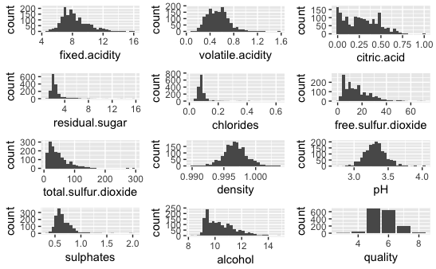

Looing at our analysis, we can see the following types of distributions: Normal: Volatile.acidity, density, and pH are all skewed as normal distributions. Positively skewed: Fixed.acidity, citric.acid, free.sulfur.dioxide, total.sulfur.dioxide, suplhates, and alcohol are all skewed in long-tail. Outliers: Many of the variables have extreme outliers including suphates, total.sulfur.dioxide, chlorides, and residual.sugar. Quality: Many of the wines are in the 5 or 6 quality range. This seems to suggest that there aren’t many terribl tasting red wines on this list, and only a few great tasting ones.

To place the positively skewed distributions into a normal distribution, we can call the sqrt command to make this change.

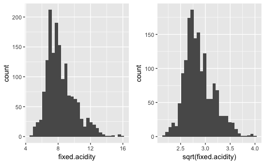

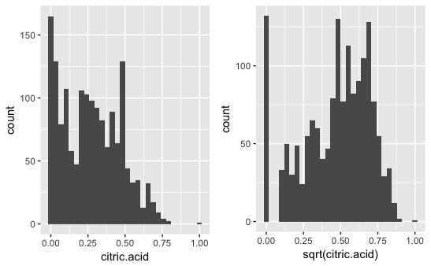

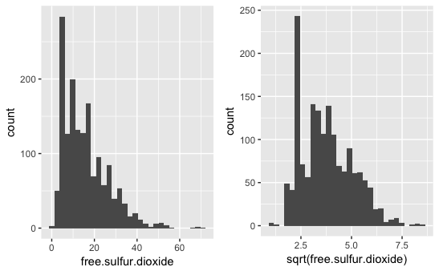

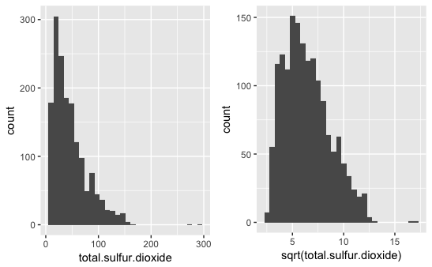

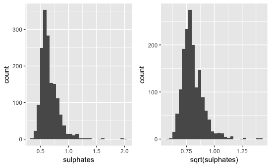

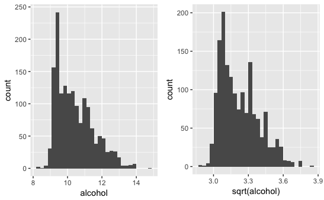

# Univariate Analysis

### What is the structure of your dataset?

There are 12 variables, with 1,599 observations.

### What is/are the main feature(s) of interest in your dataset?

The main interest in the dataset is what variables positively and negatively affect the quality of red wine.

### What other features in the dataset do you think will help support your investigation into your feature(s) of interest?

I believe that factors including, but not limited to alcohol, density, residual sugar, and pH will make a difference in the quality of the wine.

### Of the features you investigated, were there any unusual distributions?

The Fixed.acidity, citric.acid, free.sulfur.dioxide, total.sulfur.dioxide, suplhates, and alcohol variables were positively skewed and later converted into a more normal distribution.

Suphates, total.sulfur.dioxide, chlorides, and residual.sugar all had extreme outliers.

Did you perform any operations on the data to tidy, adjust, or change the form of the data? If so, why did you do this?

I used the sqrt function to tidy the Fixed.acidity, citric.acid, free.sulfur.dioxide, total.sulfur.dioxide, suplhates, and alcohol variables into a normal distribution.

I removed the X variable, which was used for indexing in the dataset.

# Bivariate Plots Section

The first relationship I am interested in determining is between free.sulfur.dioxide and total.sulfur.dioxide. Not knowing much about either or how it translates into making wine, I am interested in seeing if the variables are correlated in any way.

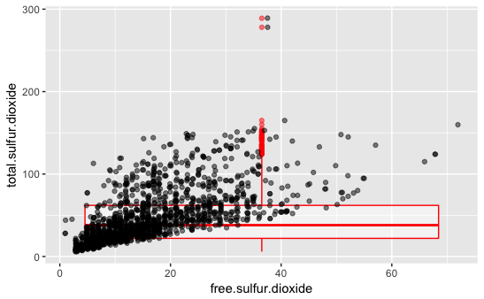

The relationship seems to show a positively correlated relationship between the free.sulfur.dioxide and total.sulfur.dioxide. As one increase, so does the other in most cases.

The next relationship I wanted to examine was between citric.acid and quality. It would seem that freshness and flavor that citric.acid brings would make the wine taste better.

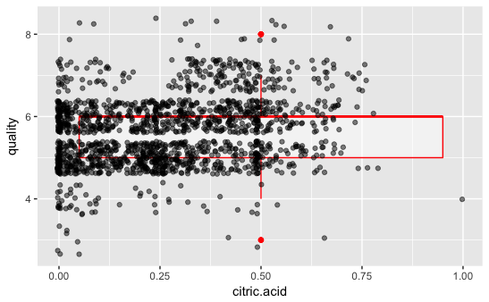

There is no strong correlation apparent between citric.acid and the quality of the wine, however, most wines have a citric acid below .5 and are between 4.5 and 6.5 in quality. A small impact relationship is present, but not enough that we can definitively say that citric.acid affects the quality of wine strongly.

I am now going to see if residual.sugar has any strong effect on the quality of wine. Taste preferences can vary for sweet or dry wine, so I believe that this will have no strong correlation to quality.

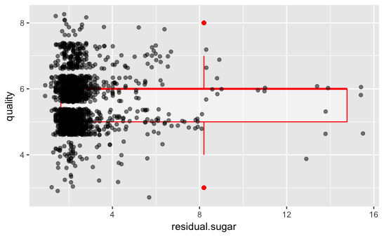

Next, I want to examine chlorides or the amount of salt in wines and see if there is any relationship to quality of the wine.

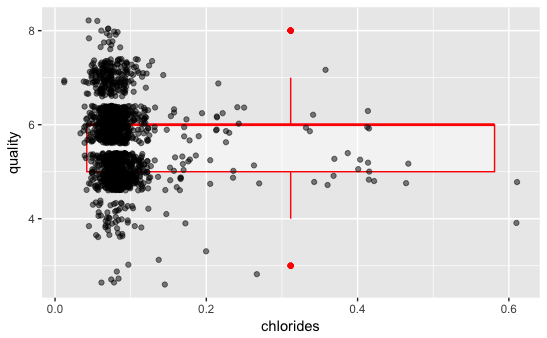

It looks like there is some correlation between the amount of chlorides in wine and the quality of the wine. The less chloride in the wine, the less salty the wine, which seems to mean a better taste. Most of the wines do not have many chlorides though, with a majority being less than 0.2. This breakdown looks fairly similar to the residual.sugar plot. Since they are similar, I want to compare the two variables on a plot.

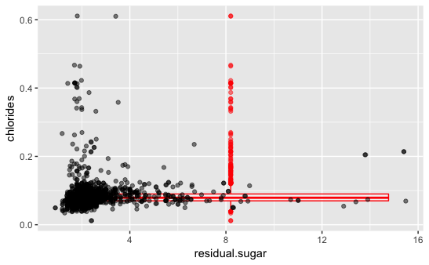

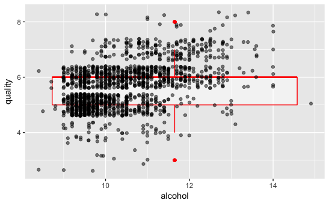

There is a strong correlation here between alcohol content and the quality of wine. As the alcohol content increases, so does the quality in most cases. Alcohol content less than 10 for the most part has a wine quality between 4.5 and 6.5, with a few outliers. As we step up in alcohol content between 10 an 12, the quality varies between 4.5 and 6.5 again, but also has a lot of wines in the 6.5 to 7.5 quality. Most wines with alcohol content greater than 12 have a quality of 6.5 or greater.

Next, I want to take a look at volatile.acidity to see if there is a relationship between this variable and the quality of wine. High amounts of volatile.acidity usually makes wine have a vinegar taste that is strong and pugnent.

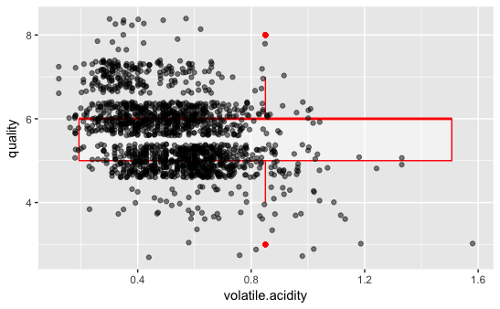

It becomes apparent that the lower volatile.acidity translates into higher quality wines, whereas higher volatile.acidity results in mostly lower quality wines. This makes sense because people want to drink wine, not drink vinegar.

Next, I want to look at fixed.acidity to see if there is correlation to wine quality.

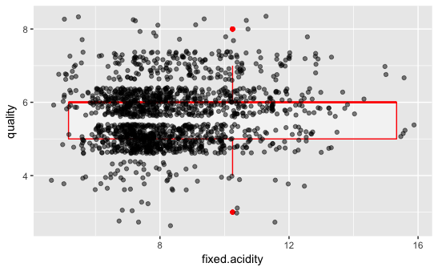

There are low amounts of fixed.acidity across the board , with most below 12 and a majority below 10. Concentrations of wine qualities of 5 and 6 are prevelant. Still, we do not see a strong correlation here, but this variable should be investigated further in the multivariate analysis section.

I want to see if density has any affect on wine quality.

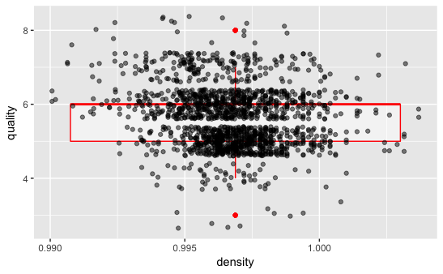

Although most of the density for the wines are between .995 and 1, there seems to be no real correlation between the density and quality of the wine.

Next, I want to investigate if pH has any effect on wine quality.

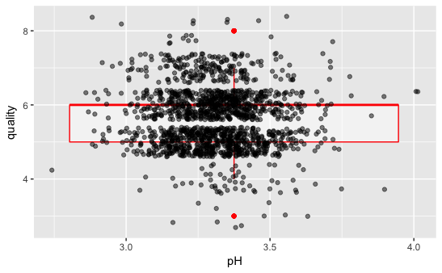

This plot looks very similar to the density plot before this one. Most of the wines are between 3 and 3.5 pH, while the quality is all over the place. I don’t see any correlation from this plot, but we will investigate further shortly.

Lastly, we will look at sulphates and it there is correlation to wine quality.

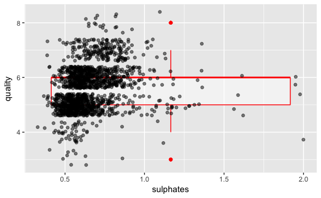

Most all of the wines are less than 1 sulphate, but the wine quality is concentrated in three spots, at 5, 6, and 7. As the number of sulphates increase, so does the quality in general. There is not enough to really say there is a strong correlation, but some relationship is evident.